# Billboard "The Hot 100" Songs Chart Data Analysis Project Introduction

Welcome to the Billboard "The Hot 100" Songs Chart Data Analysis project, where we embark on a journey through the realms of music data to unravel intriguing insights and trends. In this exploration, we leverage the power of Python's data science libraries, including Pandas, NumPy, and Matplotlib, to delve into the Billboard "The Hot 100" Songs Chart dataset. Our primary goal is to gain a deeper understanding of the dynamics that govern song popularity over time.

**Key Objectives:**

1. **Question Formulation:** We've crafted a set of intriguing questions, ranging from identifying the most frequently appearing songs to exploring the longevity and peaks of charted songs.
2. **Data Processing:** We meticulously clean and preprocess the dataset, ensuring that our analyses are built upon reliable and well-structured data.
3. **Exploratory Data Analysis:** Armed with Pandas, NumPy, and Matplotlib, we visualize trends, relationships, and anomalies, providing a visually appealing narrative of our findings.
4. **Insight Derivation:** Through queries and analyses, we derive actionable insights that uncover the underlying dynamics of song rankings and artist influence on the charts.

Join us as we navigate this musical data landscape, exploring the ebb and flow of song popularity, unraveling stories hidden in the charts, and presenting our discoveries in an accessible and engaging manner. The code, visualizations, and insights are at your fingertips, inviting you to join us on this analytical adventure.

Let the exploration begin!

```python
import numpy as np
import matplotlib.pyplot as plt
```

```python
import numpy as np
import matplotlib.pyplot as plt
import pandas as pd
import datetime
df = pd.read_csv("charts.csv")
df.describe()
```

|  | rank | last-week | peak-rank | weeks-on-board |
| --- | --- | --- | --- | --- |
| count | 330087.000000 | 297775.000000 | 330087.000000 | 330087.000000 |
| mean | 50.500929 | 47.591631 | 40.970629 | 9.161785 |
| std | 28.866094 | 28.054360 | 29.347481 | 7.618264 |
| min | 1.000000 | 1.000000 | 1.000000 | 1.000000 |
| 25% | 26.000000 | 23.000000 | 13.000000 | 4.000000 |
| 50% | 51.000000 | 47.000000 | 38.000000 | 7.000000 |
| 75% | 76.000000 | 72.000000 | 65.000000 | 13.000000 |
| max | 100.000000 | 100.000000 | 100.000000 | 90.000000 |

### About Dataset

The Billboard Hot 100 is the music industry standard record chart in the United States for songs, published weekly by Billboard magazine. Chart rankings are based on sales, radio play, and online streaming in the United States. Every week, Billboard releases "The Hot 100" chart of songs that were trending on sales and airplay for that week. This dataset is a collection of all "The Hot 100" charts released since its inception in 1958.

**Variables:**

1. date: date when the Top 100 ranking was released
2. rank: ranking of the song during that specific week of Top 100 songs
3. song: title of song
4. artist: name of the artist who released the song
5. last-week: last week song's ranking
6. peak-rank: the song's peak ranking in Top 100
7. weeks-on-board: total weeks the song stay in the ranking

```python
df.info()
```

```
<class 'pandas.core.frame.DataFrame'>
RangeIndex: 330087 entries, 0 to 330086
Data columns (total 7 columns):
 #   Column          Non-Null Count   Dtype
---  ------          --------------   -----
 0   date            330087 non-null  object
 1   rank            330087 non-null  int64
 2   song            330087 non-null  object
 3   artist          330087 non-null  object
 4   last-week       297775 non-null  float64
 5   peak-rank       330087 non-null  int64
 6   weeks-on-board  330087 non-null  int64
dtypes: float64(1), int64(3), object(3)
memory usage: 17.6+ MB
```

### Cleaning Up Dataset

- To make it easier for us to analyze the data, we cleaned up the data frame and extract the year from the "date" column
- The dataset now has an additional column called "year"

```python
import pandas as pd


# Convert the 'date' column to datetime format
df['date'] = pd.to_datetime(df['date'])

# Extract the year and store it in a new column 'year'
df['year'] = df['date'].dt.year

# Save the cleaned DataFrame to a new CSV file
df.to_csv('charts_cleaned.csv', index=False)

cleaned = pd.read_csv('charts_cleaned.csv')

cleaned
```

|  | date | rank | song | artist | last-week | peak-rank | weeks-on-board | year |
| --- | --- | --- | --- | --- | --- | --- | --- | --- |
| 0 | 2021-11-06 | 1 | Easy On Me | Adele | 1.0 | 1 | 3 | 2021 |
| 1 | 2021-11-06 | 2 | Stay | The Kid LAROI & Justin Bieber | 2.0 | 1 | 16 | 2021 |
| 2 | 2021-11-06 | 3 | Industry Baby | Lil Nas X & Jack Harlow | 3.0 | 1 | 14 | 2021 |
| 3 | 2021-11-06 | 4 | Fancy Like | Walker Hayes | 4.0 | 3 | 19 | 2021 |
| 4 | 2021-11-06 | 5 | Bad Habits | Ed Sheeran | 5.0 | 2 | 18 | 2021 |
| ... | ... | ... | ... | ... | ... | ... | ... | ... |
| 330082 | 1958-08-04 | 96 | Over And Over | Thurston Harris | NaN | 96 | 1 | 1958 |
| 330083 | 1958-08-04 | 97 | I Believe In You | Robert & Johnny | NaN | 97 | 1 | 1958 |
| 330084 | 1958-08-04 | 98 | Little Serenade | The Ames Brothers | NaN | 98 | 1 | 1958 |
| 330085 | 1958-08-04 | 99 | I'll Get By (As Long As I Have You) | Billy Williams | NaN | 99 | 1 | 1958 |
| 330086 | 1958-08-04 | 100 | Judy | Frankie Vaughan | NaN | 100 | 1 | 1958 |

330087 rows × 8 columns

# Queries

1. What is the relationship between last week rank and rank?

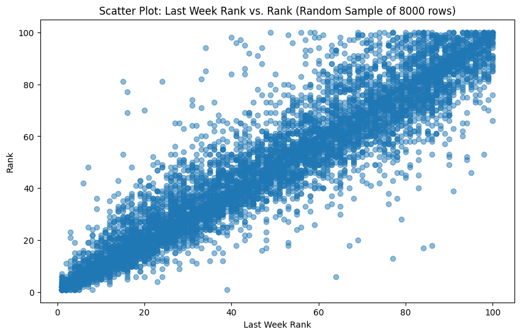

```python
# Relationship between 'last week rank' and 'rank'
sample_size = 8000
df_sample = df.sample(n=sample_size)

# Scatter plot for the relationship between 'last week rank' and 'rank'
plt.figure(figsize=(10, 6))
plt.scatter(df_sample['last-week'], df_sample['rank'], alpha=0.5)
plt.title(f'Scatter Plot: Last Week Rank vs. Rank (Random Sample of {sample_size} rows)')
plt.xlabel('Last Week Rank')
plt.ylabel('Rank')
plt.show()
```

The graph shows positive correlation between last week rank vs rank. It suggests that there is a tendency for higher values of 'last week rank' to be associated with higher values of 'rank,' and vice versa.

It could also mean that songs that were ranked high in the previous week tend to continue being ranked high in the current week. Conversely, songs with lower rankings in the previous week tend to maintain lower rankings.

2. What is the song that appear the most

```python
most_appeared_songs = cleaned['song'].value_counts().idxmax()
print("Song that appears the most:", most_appeared_songs)
```

```
Song that appears the most: Stay
```

3. Which song(s) that has the same ranking as its previous week?

```python
same_ranking_songs = cleaned[cleaned['rank'] == cleaned['last-week']]
same_ranking_songs
```

|  | date | rank | song | artist | last-week | peak-rank | weeks-on-board | year |
| --- | --- | --- | --- | --- | --- | --- | --- | --- |
| 0 | 2021-11-06 | 1 | Easy On Me | Adele | 1.0 | 1 | 3 | 2021 |
| 1 | 2021-11-06 | 2 | Stay | The Kid LAROI & Justin Bieber | 2.0 | 1 | 16 | 2021 |
| 2 | 2021-11-06 | 3 | Industry Baby | Lil Nas X & Jack Harlow | 3.0 | 1 | 14 | 2021 |
| 3 | 2021-11-06 | 4 | Fancy Like | Walker Hayes | 4.0 | 3 | 19 | 2021 |
| 4 | 2021-11-06 | 5 | Bad Habits | Ed Sheeran | 5.0 | 2 | 18 | 2021 |
| ... | ... | ... | ... | ... | ... | ... | ... | ... |
| 329887 | 1958-08-11 | 1 | Poor Little Fool | Ricky Nelson | 1.0 | 1 | 2 | 1958 |
| 329891 | 1958-08-11 | 5 | When | Kalin Twins | 5.0 | 5 | 2 | 1958 |
| 329896 | 1958-08-11 | 9 | Willie And The Hand Jive | The Johnny Otis Show | 9.0 | 9 | 2 | 1958 |
| 329915 | 1958-08-11 | 29 | Enchanted Island | The Four Lads | 29.0 | 29 | 2 | 1958 |
| 329942 | 1958-08-11 | 56 | Leroy | Jack Scott | 56.0 | 56 | 2 | 1958 |

31183 rows × 8 columns

4. Artist(s) that have multiple songs in a chart

```python
multiple_song_artists = cleaned['artist'].value_counts()[cleaned['artist'].value_counts() > 1]
multiple_song_artists
```

```
artist
Taylor Swift                                 1023
Elton John                                    889
Madonna                                       857
Drake                                         787
Kenny Chesney                                 769
                                             ...
The Flame                                       2
K'Jon                                           2
Laura Nyro                                      2
Chris Cornell                                   2
Drake Featuring Fivio Foreign & Sosa Geek       2
Name: count, Length: 9409, dtype: int64
```

5. Songs that have the biggest jump from previous week to current(most recent) week

```python
biggest_jump_song = cleaned.loc[(cleaned['last-week'] - cleaned['rank']).idxmax()]

print("Song with the biggest jump:", biggest_jump_song)
```

```
Song with the biggest jump: date                                       2019-05-11
rank                                                2
song                                              ME!
artist            Taylor Swift Featuring Brendon Urie
last-week                                       100.0
peak-rank                                           2
weeks-on-board                                      2
year                                             2019
Name: 13001, dtype: object
```

6. Longevity or peaks of songs

```python
longest_charted_song = cleaned.loc[cleaned['weeks-on-board'].idxmax()]
highest_peaked_song = cleaned.loc[cleaned['rank'].idxmin()]

print("Longest-charted song:\n", longest_charted_song)
print("")
print("Highest-peaked song:\n", highest_peaked_song)
```

```
Longest-charted song:
 date                   2021-09-04
rank                           20
song              Blinding Lights
artist                 The Weeknd
last-week                    21.0
peak-rank                       1
weeks-on-board                 90
year                         2021
Name: 919, dtype: object

Highest-peaked song:
 date              2021-11-06
rank                       1
song              Easy On Me
artist                 Adele
last-week                1.0
peak-rank                  1
weeks-on-board             3
year                    2021
Name: 0, dtype: object
```

7. Which songs stay the longest on the chart

```python
longest_staying_songs = cleaned.sort_values(by='weeks-on-board', ascending=False)

longest_staying_songs
```

|  | date | rank | song | artist | last-week | peak-rank | weeks-on-board | year |
| --- | --- | --- | --- | --- | --- | --- | --- | --- |
| 919 | 2021-09-04 | 20 | Blinding Lights | The Weeknd | 21.0 | 1 | 90 | 2021 |
| 1020 | 2021-08-28 | 21 | Blinding Lights | The Weeknd | 18.0 | 1 | 89 | 2021 |
| 1117 | 2021-08-21 | 18 | Blinding Lights | The Weeknd | 16.0 | 1 | 88 | 2021 |
| 39148 | 2014-05-10 | 49 | Radioactive | Imagine Dragons | 48.0 | 3 | 87 | 2014 |
| 1215 | 2021-08-14 | 16 | Blinding Lights | The Weeknd | 17.0 | 1 | 87 | 2021 |
| ... | ... | ... | ... | ... | ... | ... | ... | ... |
| 147587 | 1993-07-31 | 88 | Cryin' | Aerosmith | NaN | 88 | 1 | 1993 |
| 292063 | 1965-11-20 | 77 | Apple Of My Eye | Roy Head And The Traits | NaN | 77 | 1 | 1965 |
| 147584 | 1993-07-31 | 85 | Check Yo Self | Ice Cube Featuring Das EFX | NaN | 85 | 1 | 1993 |
| 292066 | 1965-11-20 | 80 | The Sound Of Silence | Simon & Garfunkel | NaN | 80 | 1 | 1965 |
| 330086 | 1958-08-04 | 100 | Judy | Frankie Vaughan | NaN | 100 | 1 | 1958 |

330087 rows × 8 columns

8. Average ranking of songs by each artist

```python
average_ranking_by_artist = cleaned.groupby('artist')['rank'].mean().round().sort_values()

print("Average ranking of songs by each artist:\n", average_ranking_by_artist)
```

```
Average ranking of songs by each artist:
 artist
The Kid LAROI & Justin Bieber            2.0
Drake Featuring Future & Young Thug      4.0
Lil Nas X & Jack Harlow                  5.0
Doja Cat Featuring SZA                   7.0
Brandy & Monica                          9.0
                                       ...
Rick Ross Featuring Ne-Yo              100.0
Mocca Soul                             100.0
Britny Fox                             100.0
Halsey Featuring Lauren Jauregui       100.0
Taylor John Williams                   100.0
Name: rank, Length: 10205, dtype: float64
```

9. Comparison between Justin Bieber and The Weeknd Songs Weeks on Board throughout the years

Step 1: Finding Justin Bieber's top hit

```python
#Compare two songs (the best) from two artists and compare the two song's best ranks
jb_songs = cleaned[cleaned['artist'] == 'Justin Bieber']
jb_top_song = jb_songs['song'].value_counts().idxmax()
jb_songs
```

|  | date | rank | song | artist | last-week | peak-rank | weeks-on-board | year |
| --- | --- | --- | --- | --- | --- | --- | --- | --- |
| 36 | 2021-11-06 | 37 | Ghost | Justin Bieber | 38.0 | 32 | 5 | 2021 |
| 137 | 2021-10-30 | 38 | Ghost | Justin Bieber | 32.0 | 32 | 4 | 2021 |
| 231 | 2021-10-23 | 32 | Ghost | Justin Bieber | 93.0 | 32 | 3 | 2021 |
| 392 | 2021-10-16 | 93 | Ghost | Justin Bieber | NaN | 66 | 2 | 2021 |
| 2196 | 2021-06-12 | 97 | Hold On | Justin Bieber | 86.0 | 20 | 13 | 2021 |
| ... | ... | ... | ... | ... | ... | ... | ... | ... |
| 63544 | 2009-09-05 | 45 | One Time | Justin Bieber | 63.0 | 45 | 5 | 2009 |
| 63662 | 2009-08-29 | 63 | One Time | Justin Bieber | 62.0 | 62 | 4 | 2009 |
| 63761 | 2009-08-22 | 62 | One Time | Justin Bieber | 78.0 | 62 | 3 | 2009 |
| 63877 | 2009-08-15 | 78 | One Time | Justin Bieber | NaN | 78 | 2 | 2009 |
| 64194 | 2009-07-25 | 95 | One Time | Justin Bieber | NaN | 95 | 1 | 2009 |

329 rows × 8 columns

Step 2: Finding The Weeknd's top hit

```python
theweeknd_songs = cleaned[df['artist'] == 'The Weeknd']
theweeknd_top_song = theweeknd_songs['song'].value_counts().idxmax()
theweeknd_songs
```

|  | date | rank | song | artist | last-week | peak-rank | weeks-on-board | year |
| --- | --- | --- | --- | --- | --- | --- | --- | --- |
| 31 | 2021-11-06 | 32 | Take My Breath | The Weeknd | 27.0 | 6 | 12 | 2021 |
| 126 | 2021-10-30 | 27 | Take My Breath | The Weeknd | 24.0 | 6 | 11 | 2021 |
| 223 | 2021-10-23 | 24 | Take My Breath | The Weeknd | 22.0 | 6 | 10 | 2021 |
| 321 | 2021-10-16 | 22 | Take My Breath | The Weeknd | 22.0 | 6 | 9 | 2021 |
| 421 | 2021-10-09 | 22 | Take My Breath | The Weeknd | 21.0 | 6 | 8 | 2021 |
| ... | ... | ... | ... | ... | ... | ... | ... | ... |
| 46468 | 2012-12-15 | 69 | Wicked Games | The Weeknd | 73.0 | 69 | 5 | 2012 |
| 46572 | 2012-12-08 | 73 | Wicked Games | The Weeknd | 81.0 | 73 | 4 | 2012 |
| 46680 | 2012-12-01 | 81 | Wicked Games | The Weeknd | 91.0 | 81 | 3 | 2012 |
| 46790 | 2012-11-24 | 91 | Wicked Games | The Weeknd | 96.0 | 91 | 2 | 2012 |
| 46895 | 2012-11-17 | 96 | Wicked Games | The Weeknd | NaN | 96 | 1 | 2012 |

477 rows × 8 columns

Step 3: Sort The Weeknd's songs by rank from highest to lowest rank

```python
cleaned[(cleaned['artist'] == 'The Weeknd')].sort_values(by = 'rank')
```

|  | date | rank | song | artist | last-week | peak-rank | weeks-on-board | year |
| --- | --- | --- | --- | --- | --- | --- | --- | --- |
| 31300 | 2015-11-07 | 1 | The Hills | The Weeknd | 1.0 | 1 | 22 | 2015 |
| 32100 | 2015-09-12 | 1 | Can't Feel My Face | The Weeknd | 2.0 | 1 | 12 | 2015 |
| 9900 | 2019-12-14 | 1 | Heartless | The Weeknd | 32.0 | 1 | 2 | 2019 |
| 31500 | 2015-10-24 | 1 | The Hills | The Weeknd | 1.0 | 1 | 20 | 2015 |
| 31600 | 2015-10-17 | 1 | The Hills | The Weeknd | 1.0 | 1 | 19 | 2015 |
| ... | ... | ... | ... | ... | ... | ... | ... | ... |
| 22398 | 2017-07-29 | 99 | Reminder | The Weeknd | 91.0 | 31 | 10 | 2017 |
| 8599 | 2020-03-21 | 100 | After Hours | The Weeknd | 66.0 | 20 | 4 | 2020 |
| 30099 | 2016-02-06 | 100 | Acquainted | The Weeknd | NaN | 60 | 4 | 2016 |
| 22199 | 2017-08-12 | 100 | Reminder | The Weeknd | 90.0 | 31 | 12 | 2017 |
| 32099 | 2015-09-19 | 100 | In The Night | The Weeknd | NaN | 100 | 1 | 2015 |

477 rows × 8 columns

Step 4: Group the songs by year and display the max weeks on board for that year

```python
weeknd_py = cleaned[(cleaned['artist'] == 'The Weeknd')].sort_values(by = 'rank')
weeknd_py = weeknd_py.groupby('year').max('weeks-on-board')
print(weeknd_py)
```

```
      rank  last-week  peak-rank  weeks-on-board
year
2012    96       96.0         96               7
2013    76       71.0         58              20
2014    99       99.0         97               9
2015   100       87.0        100              43
2016   100      100.0         72              48
2017   100      100.0         34              19
2018    95       95.0         52              18
2019    63       52.0         32               4
2020   100       80.0         80              55
2021    95       95.0         41              90
```

Step 5: Sort Justin Bieber songs by rank from highest to lowest rank

```python
cleaned[(cleaned['artist'] == 'Justin Bieber') ].sort_values(by = 'rank')
```

|  | date | rank | song | artist | last-week | peak-rank | weeks-on-board | year |
| --- | --- | --- | --- | --- | --- | --- | --- | --- |
| 29700 | 2016-02-27 | 1 | Love Yourself | Justin Bieber | 2.0 | 1 | 13 | 2016 |
| 30200 | 2016-01-23 | 1 | Sorry | Justin Bieber | 2.0 | 1 | 11 | 2016 |
| 30100 | 2016-01-30 | 1 | Sorry | Justin Bieber | 1.0 | 1 | 12 | 2016 |
| 32000 | 2015-09-19 | 1 | What Do You Mean? | Justin Bieber | NaN | 1 | 1 | 2015 |
| 30000 | 2016-02-06 | 1 | Sorry | Justin Bieber | 1.0 | 1 | 13 | 2016 |
| ... | ... | ... | ... | ... | ... | ... | ... | ... |
| 8897 | 2020-02-29 | 98 | Habitual | Justin Bieber | NaN | 98 | 1 | 2020 |
| 55698 | 2011-03-12 | 99 | U Smile | Justin Bieber | 94.0 | 27 | 4 | 2011 |
| 30599 | 2016-01-02 | 100 | Purpose | Justin Bieber | 85.0 | 43 | 5 | 2016 |
| 40599 | 2014-02-01 | 100 | All That Matters | Justin Bieber | 92.0 | 24 | 8 | 2014 |
| 8899 | 2020-02-29 | 100 | All Around Me | Justin Bieber | NaN | 100 | 1 | 2020 |

329 rows × 8 columns

Step 6: Group the songs by year and display the max weeks on board for that year

```python
jb_py = cleaned[(cleaned['artist'] == 'Justin Bieber')].sort_values(by = 'rank')
jb_py = jb_py.groupby('year').max('weeks-on-board')
print(jb_py)
```

```
      rank  last-week  peak-rank  weeks-on-board
year
2009    95       86.0         95              21
2010    95       73.0         92              25
2011    99       96.0         91               8
2012    92       53.0         60              20
2013    98       77.0         98               3
2014   100       92.0         24               8
2015    98       83.0         98              15
2016   100      100.0         53              42
2020   100       94.0        100              15
2021    97       93.0         91              17
```

Step 7: Plot the graph for The Weeknd's Songs

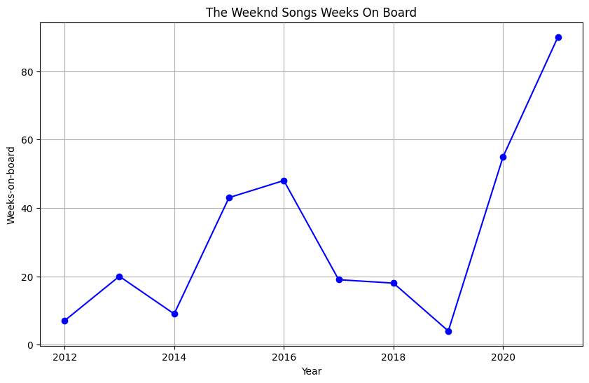

```python
weeknd = weeknd_py.reset_index()
plt.figure(figsize=(10, 6))
plt.plot(weeknd['year'],weeknd['weeks-on-board'],marker='o', linestyle='-', color='b')
plt.title(f'The Weeknd Songs Weeks On Board')
plt.xlabel('Year')
plt.ylabel('Weeks-on-board')
plt.grid(True)
plt.show()
```

Step 8: Plot the graph for Justin Bieber's songs

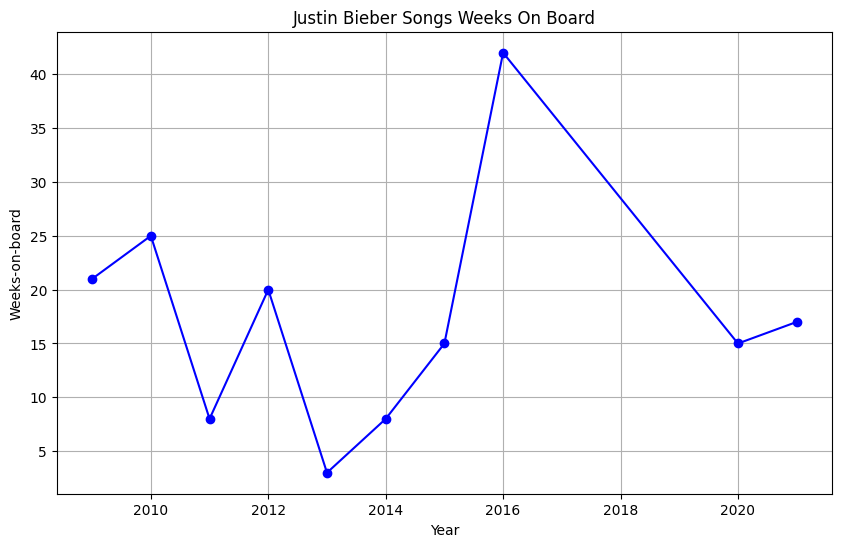

```python
jb = jb_py.reset_index()
plt.figure(figsize=(10, 6))
plt.plot(jb['year'],jb['weeks-on-board'],marker='o', linestyle='-', color='b')
plt.title(f'Justin Bieber Songs Weeks On Board')
plt.xlabel('Year')
plt.ylabel('Weeks-on-board')
plt.grid(True)
plt.show()
```

Step 9: Compare both of the graphs

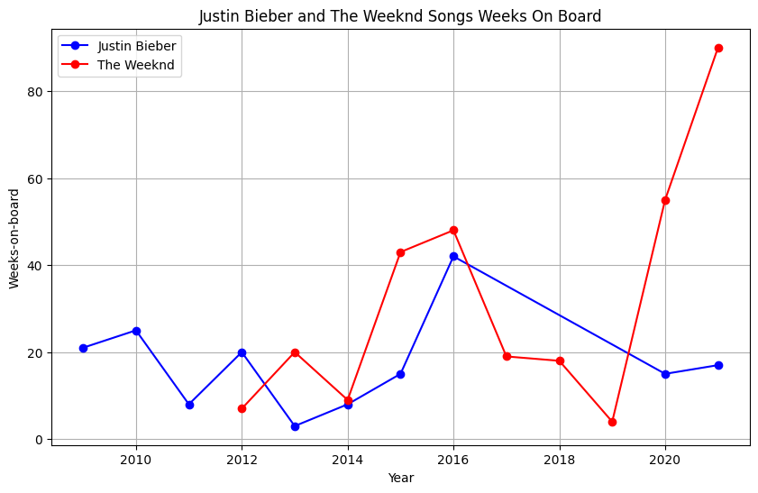

```python
jb = jb_py.reset_index()
plt.figure(figsize=(10, 6))
plt.plot(jb['year'], jb['weeks-on-board'], marker='o', linestyle='-', color='b', label='Justin Bieber')
plt.title('Justin Bieber and The Weeknd Songs Weeks On Board')
plt.xlabel('Year')
plt.ylabel('Weeks-on-board')
plt.grid(True)

weeknd = weeknd_py.reset_index()
plt.plot(weeknd['year'], weeknd['weeks-on-board'], marker='o', linestyle='-', color='r', label='The Weeknd')

plt.legend()

plt.show()
```

10. What is the trend for Ed Sheeran's 'Bad Habits' rank throughout the year 2021?

To tackle this question, we filter the dataset to find the song "Bad Habits" by Ed Sheeran first and then we plot a graph to visualize the result and check our findings:

**Filter dataset:**

```python
eds_badhabit = df.loc[df['song'].str.contains('Bad Habits', na=False) & (df['artist'] == "Ed Sheeran")]
eds_badhabit
```

|  | date | rank | song | artist | last-week | peak-rank | weeks-on-board | year |
| --- | --- | --- | --- | --- | --- | --- | --- | --- |
| 4 | 2021-11-06 | 5 | Bad Habits | Ed Sheeran | 5.0 | 2 | 18 | 2021 |
| 104 | 2021-10-30 | 5 | Bad Habits | Ed Sheeran | 4.0 | 2 | 17 | 2021 |
| 203 | 2021-10-23 | 4 | Bad Habits | Ed Sheeran | 5.0 | 2 | 16 | 2021 |
| 304 | 2021-10-16 | 5 | Bad Habits | Ed Sheeran | 6.0 | 2 | 15 | 2021 |
| 405 | 2021-10-09 | 6 | Bad Habits | Ed Sheeran | 4.0 | 2 | 14 | 2021 |
| 503 | 2021-10-02 | 4 | Bad Habits | Ed Sheeran | 3.0 | 2 | 13 | 2021 |
| 602 | 2021-09-25 | 3 | Bad Habits | Ed Sheeran | 13.0 | 2 | 12 | 2021 |
| 712 | 2021-09-18 | 13 | Bad Habits | Ed Sheeran | 3.0 | 2 | 11 | 2021 |
| 802 | 2021-09-11 | 3 | Bad Habits | Ed Sheeran | 2.0 | 2 | 10 | 2021 |
| 901 | 2021-09-04 | 2 | Bad Habits | Ed Sheeran | 2.0 | 2 | 9 | 2021 |
| 1001 | 2021-08-28 | 2 | Bad Habits | Ed Sheeran | 3.0 | 2 | 8 | 2021 |
| 1102 | 2021-08-21 | 3 | Bad Habits | Ed Sheeran | 5.0 | 3 | 7 | 2021 |
| 1204 | 2021-08-14 | 5 | Bad Habits | Ed Sheeran | 7.0 | 5 | 6 | 2021 |
| 1306 | 2021-08-07 | 7 | Bad Habits | Ed Sheeran | 6.0 | 5 | 5 | 2021 |
| 1405 | 2021-07-31 | 6 | Bad Habits | Ed Sheeran | 6.0 | 5 | 4 | 2021 |
| 1505 | 2021-07-24 | 6 | Bad Habits | Ed Sheeran | 6.0 | 5 | 3 | 2021 |
| 1605 | 2021-07-17 | 6 | Bad Habits | Ed Sheeran | 5.0 | 5 | 2 | 2021 |
| 1704 | 2021-07-10 | 5 | Bad Habits | Ed Sheeran | NaN | 5 | 1 | 2021 |

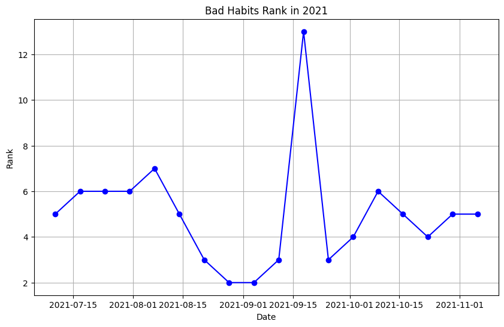

```python
specific_song = 'Bad Habits'
specific_year = 2021
specific_artist = 'Ed Sheeran'

song_data = df[(df['song'] == specific_song) & (df['year'] == specific_year) & (df['artist'] == specific_artist)]

# Plotting the graph
plt.figure(figsize=(10, 6))
plt.plot(song_data['date'],song_data['rank'],marker='o', linestyle='-', color='b')
plt.title(f'{specific_song} Rank in {specific_year}')
plt.xlabel('Date')
plt.ylabel('Rank')
plt.grid(True)
plt.show()
```